# Uber Data Analysis

Piyush Kumar

2022-02-01

# Uber Data Analysis (using different plots and geographical plotting)

## Attaching Necessary Libraries

```r
library(ggplot2)
library(lubridate)
library(dplyr)
library(tidyr)
library(DT)
library(scales)
library(sf)
library(mapview)
```

## Importing Data Files (.csv extension) and preparing data for analysis

```r
apr <- read.csv("uber-raw-data-apr14.csv")
may <- read.csv("uber-raw-data-may14.csv")
june <- read.csv("uber-raw-data-jun14.csv")
july <- read.csv("uber-raw-data-jul14.csv")
aug <- read.csv("uber-raw-data-aug14.csv")
sept <- read.csv("uber-raw-data-sep14.csv")

uber.data= rbind(apr,may,june,july,aug,sept)

glimpse(uber.data)
```

```
## Rows: 4,534,327
## Columns: 4
## $ Date.Time <chr> "4/1/2014 0:11:00", "4/1/2014 0:17:00", "4/1/2014 0:21:00", …
## $ Lat       <dbl> 40.7690, 40.7267, 40.7316, 40.7588, 40.7594, 40.7383, 40.722…
## $ Lon       <dbl> -73.9549, -74.0345, -73.9873, -73.9776, -73.9722, -74.0403, …
## $ Base      <chr> "B02512", "B02512", "B02512", "B02512", "B02512", "B02512", …
```

```r
head(uber.data)
```

```
##          Date.Time     Lat      Lon   Base
## 1 4/1/2014 0:11:00 40.7690 -73.9549 B02512
## 2 4/1/2014 0:17:00 40.7267 -74.0345 B02512
## 3 4/1/2014 0:21:00 40.7316 -73.9873 B02512
## 4 4/1/2014 0:28:00 40.7588 -73.9776 B02512
## 5 4/1/2014 0:33:00 40.7594 -73.9722 B02512
## 6 4/1/2014 0:33:00 40.7383 -74.0403 B02512
```

## Extracting data for different time instances

```r
uber.data$Date.Time= as.POSIXct(uber.data$Date.Time,format="%m/%d/%Y %H:%M:%S")
uber.data$Time= format(uber.data$Date.Time, format = "%H:%M:%S")

uber.data$year= factor(year(uber.data$Date.Time))
uber.data$month= factor(month(uber.data$Date.Time, label=TRUE))
uber.data$dayofweek= factor(wday(uber.data$Date.Time,label=TRUE))
uber.data$day= factor(day(uber.data$Date.Time))
uber.data$hour= factor(hour(hms(uber.data$Time)))
uber.data$minute= factor(minute(hms(uber.data$Time)))
uber.data$second= factor(second(hms(uber.data$Time)))

head(uber.data)
```

```
##             Date.Time     Lat      Lon   Base     Time year month dayofweek day
## 1 2014-04-01 00:11:00 40.7690 -73.9549 B02512 00:11:00 2014   Apr       Tue   1
## 2 2014-04-01 00:17:00 40.7267 -74.0345 B02512 00:17:00 2014   Apr       Tue   1
## 3 2014-04-01 00:21:00 40.7316 -73.9873 B02512 00:21:00 2014   Apr       Tue   1
## 4 2014-04-01 00:28:00 40.7588 -73.9776 B02512 00:28:00 2014   Apr       Tue   1
## 5 2014-04-01 00:33:00 40.7594 -73.9722 B02512 00:33:00 2014   Apr       Tue   1
## 6 2014-04-01 00:33:00 40.7383 -74.0403 B02512 00:33:00 2014   Apr       Tue   1
##   hour minute second
## 1    0     11      0
## 2    0     17      0
## 3    0     21      0
## 4    0     28      0
## 5    0     33      0
## 6    0     33      0
```

```r
hourly_data= uber.data %>% group_by(hour) %>% dplyr::summarise(Total=n())
datatable(hourly_data)
```

|  | hour | Total |
| --- | --- | --- |
| 1 | 0 | 103836 |
| 2 | 1 | 67227 |
| 3 | 2 | 45865 |
| 4 | 3 | 48287 |
| 5 | 4 | 55230 |
| 6 | 5 | 83939 |
| 7 | 6 | 143213 |
| 8 | 7 | 193094 |
| 9 | 8 | 190504 |
| 10 | 9 | 159967 |

[output cut: 14 more lines]

## Plot of trips every hour (Aggregate of all months)

```r
hourly_data= uber.data %>% group_by(hour) %>% dplyr::summarise(Total=n())
datatable(hourly_data)
```

|  | hour | Total |
| --- | --- | --- |
| 1 | 0 | 103836 |
| 2 | 1 | 67227 |
| 3 | 2 | 45865 |
| 4 | 3 | 48287 |
| 5 | 4 | 55230 |
| 6 | 5 | 83939 |
| 7 | 6 | 143213 |
| 8 | 7 | 193094 |
| 9 | 8 | 190504 |
| 10 | 9 | 159967 |

[output cut: 14 more lines]

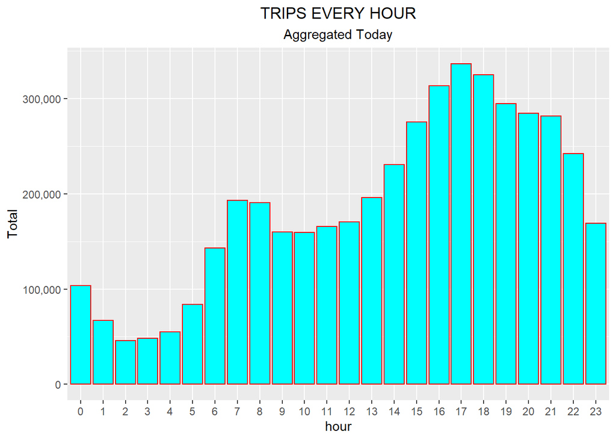

```r
ggplot(hourly_data , aes(hour,Total)) +
  geom_bar(stat="identity", fill="Cyan", color="Red") +
  ggtitle("TRIPS EVERY HOUR",subtitle="Aggregated Today") +
  theme(plot.title= element_text(hjust= 0.5),plot.subtitle= element_text(hjust=0.5)) +
  scale_y_continuous(labels=comma)
```

## Stacked barplot of trips every hour with stacks as months

```r
month_hour_data= uber.data %>% group_by(month,hour) %>% dplyr::summarise(Total=n())
datatable(month_hour_data)
```

|  | month | hour | Total |
| --- | --- | --- | --- |
| 1 | Apr | 0 | 11910 |
| 2 | Apr | 1 | 7769 |
| 3 | Apr | 2 | 4935 |
| 4 | Apr | 3 | 5040 |
| 5 | Apr | 4 | 6095 |
| 6 | Apr | 5 | 9476 |
| 7 | Apr | 6 | 18498 |
| 8 | Apr | 7 | 24924 |
| 9 | Apr | 8 | 22843 |
| 10 | Apr | 9 | 17939 |

[output cut: 134 more lines]

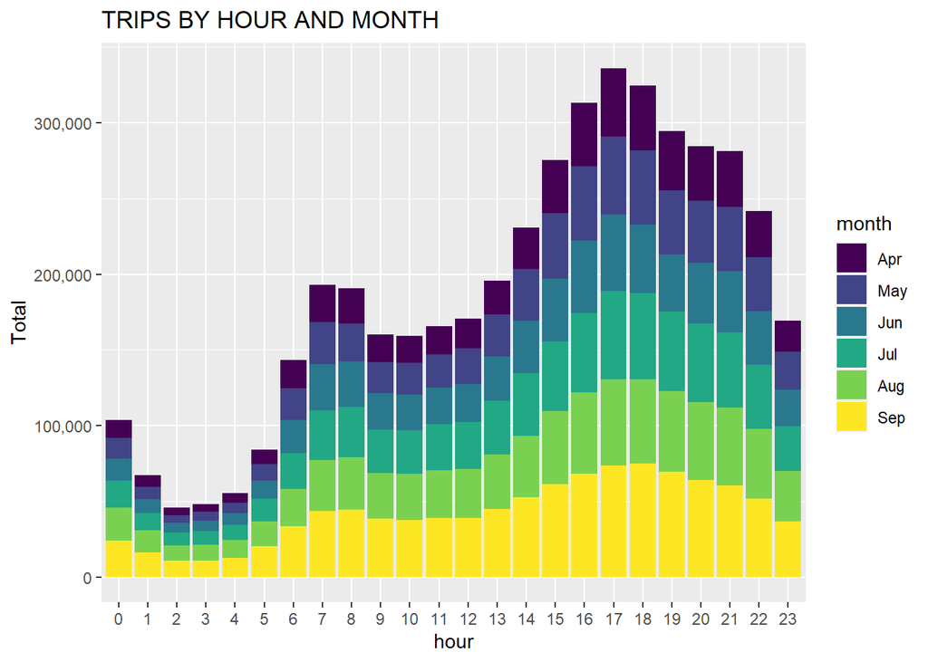

```r
ggplot(month_hour_data,aes(hour,Total, fill=month)) +
  geom_col() +
  ggtitle("TRIPS BY HOUR AND MONTH") +
  scale_y_continuous(labels=comma)
```

The above plotted stacked bar shows how no. of rides are distributed throughout the day (done earlier separately),stacked to different months. It somewhat seems that september month has highest amount of rides.

## Plot to show rides every day (Aggregate of all months)

```r
day_data <- uber.data %>% group_by(day) %>% dplyr::summarize(Trips = n())
day_data
```

```
## # A tibble: 31 × 2
##    day    Trips
##    <fct>  <int>
##  1 1     127430
##  2 2     143201
##  3 3     142983
##  4 4     140923
##  5 5     147054
##  6 6     139886
##  7 7     143503
##  8 8     145984
##  9 9     155135
## 10 10    152500
## # … with 21 more rows
```

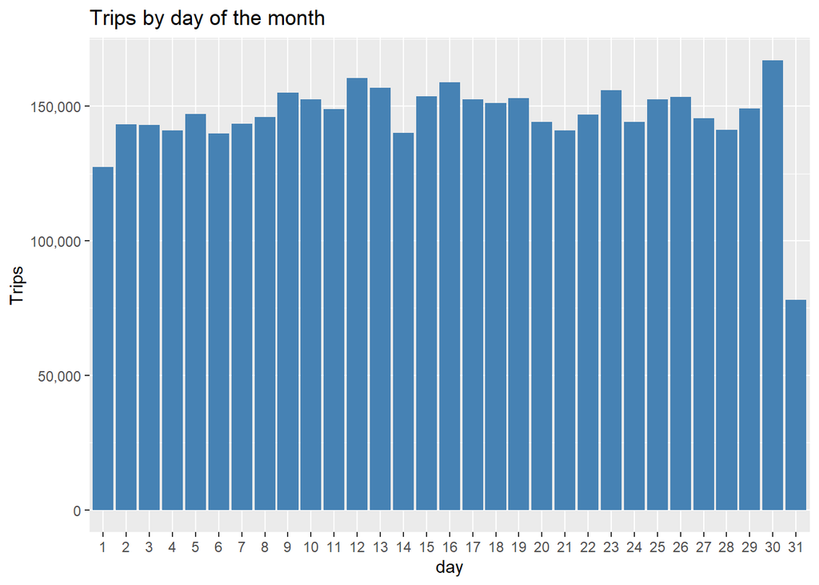

```r
ggplot(day_data, aes(day, Trips)) +
  geom_bar(stat = "identity", fill = "steelblue") +
  ggtitle("Trips by day of the month") +
  scale_y_continuous(labels = comma)
```

The above graph shows total no. of rides each day in all the months summed up. Except 31st, all the days have no. of rides above 1 lakh (it is also because not every month is 30 days long, so it makes less sense to compare it with other days)

## Clustered barplot to better visualize rides each weekday for each of the six months

```r
day_month_data <- uber.data %>% group_by(dayofweek, month) %>% dplyr::summarize(Trips = n())
day_month_data
```

```
## # A tibble: 42 × 3
## # Groups:   dayofweek [7]
##    dayofweek month  Trips
##    <ord>     <ord>  <int>
##  1 Sun       Apr    51251
##  2 Sun       May    56168
##  3 Sun       Jun    79656
##  4 Sun       Jul    76327
##  5 Sun       Aug   110246
##  6 Sun       Sep   116532
##  7 Mon       Apr    60861
##  8 Mon       May    63846
##  9 Mon       Jun    94655
## 10 Mon       Jul    93189
## # … with 32 more rows
```

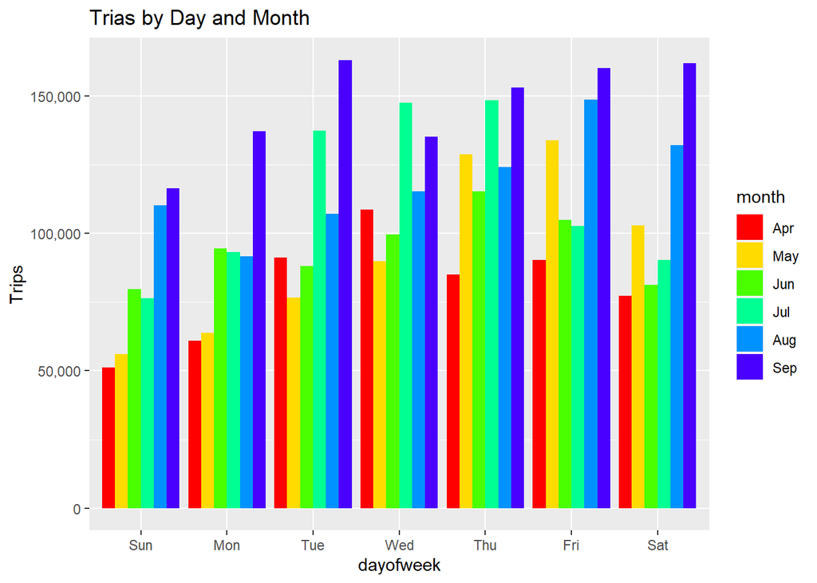

```r
ggplot(day_month_data, aes(dayofweek, Trips, fill = month)) +
  geom_bar(stat = "identity", position = "dodge") +
  ggtitle("Trias by Day and Month") +
  scale_y_continuous(labels = comma) +
  scale_fill_manual(values = rainbow(7))
```

This clustered bar plot shows how rides are distributed in a week for each of the six months we have. One can observe that most of the rides are somewhere to the middle of the week.